# Developing Data Products

7/21/2020

## BACKGROUND

### SARS-COV-2 in the United States

SARS-COV-2 is the name for the coronavirus that causes the deadly disease COVID-19. Its spread through the United States began in early 2020 and continues today. The prevalence and spread of the virus in the country have varied widely from region to region due, in part, to political and demographic differences between States. Comparing trends by region will be an important strategy in making effective policy decisions throughout the remainder of the outbreak.

## BACKGROUND

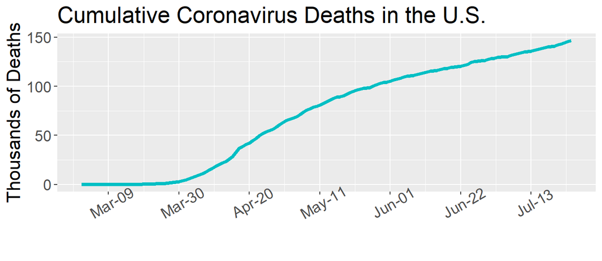

Despite efforts to curb the impact of the virus, deaths continued to climb steadily throughout June and July. The toll has now nearly reached 150,000 deaths.

## PROJECT

### U.S. COVID-19 Map Application

The goal of this project is to create an R Shiny App with the following features:

- A “snapshot” of the virus’ spread at a date selected by the user
- Ability to toggle between *total* and *per capita* cases or deaths
- Adjustable scale such that the user can view the entire U.S. or sub-regions

The app is available [here](https://ericeliassmith.shinyapps.io/Course_Project/).

## DATA

The coronavirus indicator data for the project came from the [COVID-19 Data Repository](https://github.com/CSSEGISandData/COVID-19/tree/master/csse_covid_19_data/csse_covid_19_daily_reports) maintained by the Johns Hopkins University Center for Systems Science and Engineering (JHU CSSE). JHU CSSE uses this data to operate the [2019 Novel Coronavirus Visual Dashboard](https://www.arcgis.com/apps/opsdashboard/index.html#/bda7594740fd40299423467b48e9ecf6).

The population data for the project came from the United States Census Bureau. Specifically, 2019 population estimates were used from the data set available [here](https://www2.census.gov/programs-surveys/popest/datasets/2010-2019/counties/totals/co-est2019-alldata.csv).

The code used to process these data sets is embedded in the R Markdown file that produced this presentation. It is available [here](https://github.com/1earning-R/Dev_Data_Products_Project_COVID/blob/master/pitch.Rmd).